# Описание

- Перейдём к задаче. HR-аналитики компании «Работа с заботой» помогают бизнесу оптимизировать управление персоналом: бизнес предоставляет данные, а аналитики предлагают, как избежать финансовых потерь и оттока сотрудников. В этом HR-аналитикам пригодится машинное обучение, с помощью которого получится быстрее и точнее отвечать на вопросы бизнеса.
- Компания предоставила данные с характеристиками сотрудников компании. Среди них — уровень удовлетворённости сотрудника работой в компании. Эту информацию получили из форм обратной связи: сотрудники заполняют тест-опросник, и по его результатам рассчитывается доля их удовлетворённости от 0 до 1, где 0 — совершенно неудовлетворён, 1 — полностью удовлетворён.
- Собирать данные такими опросниками не так легко: компания большая, и всех сотрудников надо сначала оповестить об опросе, а затем проследить, что все его прошли. У вас будет несколько задач.
- Первая — построить модель, которая сможет предсказать уровень удовлетворённости сотрудника на основе данных заказчика. Почему бизнесу это важно: удовлетворённость работой напрямую влияет на отток сотрудников. А предсказание оттока — одна из важнейших задач HR-аналитиков. Внезапные увольнения несут в себе риски для компании, особенно если уходит важный сотрудник.
- Ваша вторая задача — построить модель, которая сможет на основе данных заказчика предсказать то, что сотрудник уволится из компании.

# Задание 1

## Загрузка Данных

### Импорт библиотек

```python
!pip install phik
```

```python
import pandas as pd
import numpy as np
import matplotlib.pyplot as plt
import seaborn as sns
from sklearn.impute import SimpleImputer
from sklearn.pipeline import Pipeline
from sklearn.compose import ColumnTransformer
from sklearn.preprocessing import(
    StandardScaler,
    OneHotEncoder,
    OrdinalEncoder,
    MinMaxScaler,
    LabelEncoder
)
from sklearn.linear_model import LinearRegression, LogisticRegression
from sklearn.tree import DecisionTreeRegressor
from sklearn.metrics import make_scorer, roc_auc_score
from sklearn.model_selection import GridSearchCV
from sklearn.ensemble import RandomForestRegressor, RandomForestClassifier
from sklearn.neighbors import KNeighborsClassifier
from phik import phik_matrix
import statsmodels.api as sm
from statsmodels.stats.outliers_influence import variance_inflation_factor
### Константы
RANDOM_STATE = 42
```

### Выгрузка данных

```python
try:
    train_job = pd.read_csv('/datasets/train_job_satisfaction_rate.csv')
    test_features = pd.read_csv('/datasets/test_features.csv')
    test_target = pd.read_csv('/datasets/test_target_job_satisfaction_rate.csv')
except Exception as e:
    print(f'Ошибка {e}\nПроверьте импорт библиотек или путь к файлам данных')
```

### Обзор данных

#### train_job_satisfaction_rate - Тренировочная выборка:

```python
train_job.info()
```

```
<class 'pandas.core.frame.DataFrame'>
RangeIndex: 4000 entries, 0 to 3999
Data columns (total 10 columns):
 #   Column                 Non-Null Count  Dtype
---  ------                 --------------  -----
 0   id                     4000 non-null   int64
 1   dept                   3994 non-null   object
 2   level                  3996 non-null   object
 3   workload               4000 non-null   object
 4   employment_years       4000 non-null   int64
 5   last_year_promo        4000 non-null   object
 6   last_year_violations   4000 non-null   object
 7   supervisor_evaluation  4000 non-null   int64
 8   salary                 4000 non-null   int64
 9   job_satisfaction_rate  4000 non-null   float64
dtypes: float64(1), int64(4), object(5)
memory usage: 312.6+ KB
```

```python
train_job.head()
```

|  | id | dept | level | workload | employment_years | last_year_promo | last_year_violations | supervisor_evaluation | salary | job_satisfaction_rate |
| --- | --- | --- | --- | --- | --- | --- | --- | --- | --- | --- |
| 0 | 155278 | sales | junior | medium | 2 | no | no | 1 | 24000 | 0.58 |
| 1 | 653870 | hr | junior | high | 2 | no | no | 5 | 38400 | 0.76 |
| 2 | 184592 | sales | junior | low | 1 | no | no | 2 | 12000 | 0.11 |
| 3 | 171431 | technology | junior | low | 4 | no | no | 2 | 18000 | 0.37 |
| 4 | 693419 | hr | junior | medium | 1 | no | no | 3 | 22800 | 0.20 |

Мы видим следующие **признаки:**

- `id` — уникальный идентификатор сотрудника;
- `dept` — отдел, в котором работает сотрудник;
- `level` — уровень занимаемой должности;
- `workload` — уровень загруженности сотрудника;
- `employment_years` — длительность работы в компании (в годах);
- `last_year_promo` — показывает, было ли повышение за последний год;
- `last_year_violations` — показывает, нарушал ли сотрудник трудовой договор за последний год;
- `supervisor_evaluation` — оценка качества работы сотрудника, которую дал руководитель;
- `salary` — ежемесячная зарплата сотрудника;
- `job_satisfaction_rate` — уровень удовлетворённости сотрудника работой в компании, целевой признак.

```python
test_features.info()
```

```
<class 'pandas.core.frame.DataFrame'>
RangeIndex: 2000 entries, 0 to 1999
Data columns (total 9 columns):
 #   Column                 Non-Null Count  Dtype
---  ------                 --------------  -----
 0   id                     2000 non-null   int64
 1   dept                   1998 non-null   object
 2   level                  1999 non-null   object
 3   workload               2000 non-null   object
 4   employment_years       2000 non-null   int64
 5   last_year_promo        2000 non-null   object
 6   last_year_violations   2000 non-null   object
 7   supervisor_evaluation  2000 non-null   int64
 8   salary                 2000 non-null   int64
dtypes: int64(4), object(5)
memory usage: 140.8+ KB
```

```python
test_features.head()
```

|  | id | dept | level | workload | employment_years | last_year_promo | last_year_violations | supervisor_evaluation | salary |
| --- | --- | --- | --- | --- | --- | --- | --- | --- | --- |
| 0 | 485046 | marketing | junior | medium | 2 | no | no | 5 | 28800 |
| 1 | 686555 | hr | junior | medium | 1 | no | no | 4 | 30000 |
| 2 | 467458 | sales | middle | low | 5 | no | no | 4 | 19200 |
| 3 | 418655 | sales | middle | low | 6 | no | no | 4 | 19200 |
| 4 | 789145 | hr | middle | medium | 5 | no | no | 5 | 40800 |

Признакововое описание и содержание аналогично **train_job_satisfaction_rate** за исключением целевого признака `job_satisfaction_rate`.

#### test_target_job_satisfaction_rate - Целевой признак тестовой выборки:

```python
test_target.info()
```

```
<class 'pandas.core.frame.DataFrame'>
RangeIndex: 2000 entries, 0 to 1999
Data columns (total 2 columns):
 #   Column                 Non-Null Count  Dtype
---  ------                 --------------  -----
 0   id                     2000 non-null   int64
 1   job_satisfaction_rate  2000 non-null   float64
dtypes: float64(1), int64(1)
memory usage: 31.4 KB
```

```python
test_target.head()
```

|  | id | job_satisfaction_rate |
| --- | --- | --- |
| 0 | 130604 | 0.74 |
| 1 | 825977 | 0.75 |
| 2 | 418490 | 0.60 |
| 3 | 555320 | 0.72 |
| 4 | 826430 | 0.08 |

Этот датасет получился путем откалывание целевого признака от **test_features**.

### Выводы:

Загрузили 3 датасета, разделенные для обучения, предсказания и оценки модели по целевому признаку `job_satisfaction_rate`. Видим небольшое кол-во пропусков в тренировочном и тестовом датасетах, но не критично.

Имеем следующее описание **признаков**:

- `id` — уникальный идентификатор сотрудника;
- `dept` — отдел, в котором работает сотрудник;
- `level` — уровень занимаемой должности;
- `workload` — уровень загруженности сотрудника;
- `employment_years` — длительность работы в компании (в годах);
- `last_year_promo` — показывает, было ли повышение за последний год;
- `last_year_violations` — показывает, нарушал ли сотрудник трудовой договор за последний год;
- `supervisor_evaluation` — оценка качества работы сотрудника, которую дал руководитель;
- `salary` — ежемесячная зарплата сотрудника;
- `job_satisfaction_rate` — уровень удовлетворённости сотрудника работой в компании, целевой признак.

## Предобработка данных

### train_job

```python
print(train_job.info())
train_job.head()
```

```
<class 'pandas.core.frame.DataFrame'>
RangeIndex: 4000 entries, 0 to 3999
Data columns (total 10 columns):
 #   Column                 Non-Null Count  Dtype
---  ------                 --------------  -----
 0   id                     4000 non-null   int64
 1   dept                   3994 non-null   object
 2   level                  3996 non-null   object
 3   workload               4000 non-null   object
 4   employment_years       4000 non-null   int64
 5   last_year_promo        4000 non-null   object
 6   last_year_violations   4000 non-null   object
 7   supervisor_evaluation  4000 non-null   int64
 8   salary                 4000 non-null   int64
 9   job_satisfaction_rate  4000 non-null   float64
dtypes: float64(1), int64(4), object(5)
memory usage: 312.6+ KB
None
```

|  | id | dept | level | workload | employment_years | last_year_promo | last_year_violations | supervisor_evaluation | salary | job_satisfaction_rate |
| --- | --- | --- | --- | --- | --- | --- | --- | --- | --- | --- |
| 0 | 155278 | sales | junior | medium | 2 | no | no | 1 | 24000 | 0.58 |
| 1 | 653870 | hr | junior | high | 2 | no | no | 5 | 38400 | 0.76 |
| 2 | 184592 | sales | junior | low | 1 | no | no | 2 | 12000 | 0.11 |
| 3 | 171431 | technology | junior | low | 4 | no | no | 2 | 18000 | 0.37 |
| 4 | 693419 | hr | junior | medium | 1 | no | no | 3 | 22800 | 0.20 |

- Названия столбцов корректные, пропусков очень мало, заполним их Пайплайном на последнем шаге этого раздела
- Далее проверим на неявные дубликаты категориальные признаки и на явные дубликаты

```python
for i in train_job.select_dtypes(exclude=['int64', 'float64']).columns:
    print(f'Unique values of featrue {i}: {train_job[i].unique()}')
len(train_job.duplicated()) - len(train_job)
```

```
Unique values of featrue dept: ['sales' 'hr' 'technology' 'purchasing' 'marketing' nan]
Unique values of featrue level: ['junior' 'middle' 'sinior' nan]
Unique values of featrue workload: ['medium' 'high' 'low']
Unique values of featrue last_year_promo: ['no' 'yes']
Unique values of featrue last_year_violations: ['no' 'yes']
```

```
0
```

Нет ни явных, ни неявных дубликатов, в целом все хорошо, поэтому пойдем дальше.

### test_features

Текущий датафрейм почти аналогичен предыдущему по структуре, поэтому опостим вышеупомянутые шаги:

```python
print(test_features.info())
test_features.head()
```

```
<class 'pandas.core.frame.DataFrame'>
RangeIndex: 2000 entries, 0 to 1999
Data columns (total 9 columns):
 #   Column                 Non-Null Count  Dtype
---  ------                 --------------  -----
 0   id                     2000 non-null   int64
 1   dept                   1998 non-null   object
 2   level                  1999 non-null   object
 3   workload               2000 non-null   object
 4   employment_years       2000 non-null   int64
 5   last_year_promo        2000 non-null   object
 6   last_year_violations   2000 non-null   object
 7   supervisor_evaluation  2000 non-null   int64
 8   salary                 2000 non-null   int64
dtypes: int64(4), object(5)
memory usage: 140.8+ KB
None
```

|  | id | dept | level | workload | employment_years | last_year_promo | last_year_violations | supervisor_evaluation | salary |
| --- | --- | --- | --- | --- | --- | --- | --- | --- | --- |
| 0 | 485046 | marketing | junior | medium | 2 | no | no | 5 | 28800 |
| 1 | 686555 | hr | junior | medium | 1 | no | no | 4 | 30000 |
| 2 | 467458 | sales | middle | low | 5 | no | no | 4 | 19200 |
| 3 | 418655 | sales | middle | low | 6 | no | no | 4 | 19200 |
| 4 | 789145 | hr | middle | medium | 5 | no | no | 5 | 40800 |

```python
for i in test_features.select_dtypes(exclude=['int64', 'float64']).columns:
    print(f'Unique values of featrue {i}: {test_features[i].unique()}')
len(test_features.duplicated()) - len(test_features)
```

```
Unique values of featrue dept: ['marketing' 'hr' 'sales' 'purchasing' 'technology' nan ' ']
Unique values of featrue level: ['junior' 'middle' 'sinior' nan]
Unique values of featrue workload: ['medium' 'low' 'high' ' ']
Unique values of featrue last_year_promo: ['no' 'yes']
Unique values of featrue last_year_violations: ['no' 'yes']
```

```
0
```

Здесь же мы видим в признаках `dept` и `workload` проблы, посмотрим на эти строки:

```python
test_features.query('dept == " " or workload == " "')
```

|  | id | dept | level | workload | employment_years | last_year_promo | last_year_violations | supervisor_evaluation | salary |
| --- | --- | --- | --- | --- | --- | --- | --- | --- | --- |
| 15 | 590867 | marketing | junior |  | 4 | no | no | 4 | 28800 |
| 1699 | 822186 |  | middle | medium | 3 | no | no | 4 | 38400 |

Ничего необычного, простые пропуски, которые заполнились пробелами, обозначим их, дабы не путаться в дальнейшем:

```python
test_features['dept'] = test_features.dept.apply(lambda x: np.nan if x == ' ' else x)
test_features['workload'] = test_features.workload.apply(lambda x: np.nan if x == ' ' else x)
for i in test_features.select_dtypes(exclude=['int64', 'float64']).columns:
    print(f'Unique values of featrue {i}: {test_features[i].unique()}')
```

```
Unique values of featrue dept: ['marketing' 'hr' 'sales' 'purchasing' 'technology' nan]
Unique values of featrue level: ['junior' 'middle' 'sinior' nan]
Unique values of featrue workload: ['medium' 'low' 'high' nan]
Unique values of featrue last_year_promo: ['no' 'yes']
Unique values of featrue last_year_violations: ['no' 'yes']
```

Здесь ситуация практически аналогична выводу по предыдущему датафрейму, за исключением обработки 2 неявных пропусков.

### test_target

Посмотрим на названия столбцов и пропуски:

```python
print(test_target.info())
test_target.head()
```

```
<class 'pandas.core.frame.DataFrame'>
RangeIndex: 2000 entries, 0 to 1999
Data columns (total 2 columns):
 #   Column                 Non-Null Count  Dtype
---  ------                 --------------  -----
 0   id                     2000 non-null   int64
 1   job_satisfaction_rate  2000 non-null   float64
dtypes: float64(1), int64(1)
memory usage: 31.4 KB
None
```

|  | id | job_satisfaction_rate |
| --- | --- | --- |
| 0 | 130604 | 0.74 |
| 1 | 825977 | 0.75 |
| 2 | 418490 | 0.60 |
| 3 | 555320 | 0.72 |
| 4 | 826430 | 0.08 |

Датафрейм предобработан

### Заполним пропуски при помощи PipeLine:

```python
categorical_features = ['dept', 'level', 'workload']

pipeline = Pipeline([
    ('imputer', SimpleImputer(strategy='most_frequent'))
])

train_job[categorical_features] = pipeline.fit_transform(train_job[categorical_features])
test_features[categorical_features] = pipeline.transform(test_features[categorical_features])
print(train_job.info(), f'\n{50 * "-"}')
test_features.info()
```

```
<class 'pandas.core.frame.DataFrame'>
RangeIndex: 4000 entries, 0 to 3999
Data columns (total 10 columns):
 #   Column                 Non-Null Count  Dtype
---  ------                 --------------  -----
 0   id                     4000 non-null   int64
 1   dept                   4000 non-null   object
 2   level                  4000 non-null   object
 3   workload               4000 non-null   object
 4   employment_years       4000 non-null   int64
 5   last_year_promo        4000 non-null   object
 6   last_year_violations   4000 non-null   object
 7   supervisor_evaluation  4000 non-null   int64
 8   salary                 4000 non-null   int64
 9   job_satisfaction_rate  4000 non-null   float64
dtypes: float64(1), int64(4), object(5)
memory usage: 312.6+ KB
None
--------------------------------------------------
<class 'pandas.core.frame.DataFrame'>
RangeIndex: 2000 entries, 0 to 1999
Data columns (total 9 columns):
 #   Column                 Non-Null Count  Dtype
---  ------                 --------------  -----
 0   id                     2000 non-null   int64
 1   dept                   2000 non-null   object
 2   level                  2000 non-null   object
 3   workload               2000 non-null   object
 4   employment_years       2000 non-null   int64
 5   last_year_promo        2000 non-null   object
 6   last_year_violations   2000 non-null   object
 7   supervisor_evaluation  2000 non-null   int64
 8   salary                 2000 non-null   int64
dtypes: int64(4), object(5)
memory usage: 140.8+ KB
```

```python
display(train_job.head())
test_features.head()
```

|  | id | dept | level | workload | employment_years | last_year_promo | last_year_violations | supervisor_evaluation | salary | job_satisfaction_rate |
| --- | --- | --- | --- | --- | --- | --- | --- | --- | --- | --- |
| 0 | 155278 | sales | junior | medium | 2 | no | no | 1 | 24000 | 0.58 |
| 1 | 653870 | hr | junior | high | 2 | no | no | 5 | 38400 | 0.76 |
| 2 | 184592 | sales | junior | low | 1 | no | no | 2 | 12000 | 0.11 |
| 3 | 171431 | technology | junior | low | 4 | no | no | 2 | 18000 | 0.37 |
| 4 | 693419 | hr | junior | medium | 1 | no | no | 3 | 22800 | 0.20 |

|  | id | dept | level | workload | employment_years | last_year_promo | last_year_violations | supervisor_evaluation | salary |
| --- | --- | --- | --- | --- | --- | --- | --- | --- | --- |
| 0 | 485046 | marketing | junior | medium | 2 | no | no | 5 | 28800 |
| 1 | 686555 | hr | junior | medium | 1 | no | no | 4 | 30000 |
| 2 | 467458 | sales | middle | low | 5 | no | no | 4 | 19200 |
| 3 | 418655 | sales | middle | low | 6 | no | no | 4 | 19200 |
| 4 | 789145 | hr | middle | medium | 5 | no | no | 5 | 40800 |

### Выводы:

Мы получили достаточно хорошие данные по качеству предоставления данных, очень мало пропусков, которые заполнили при помощи пайплайна и **SimpleImputer**, в датафрейме `test_features` мы предобработали неявные пропуски, в остальном все отлично.

## Исследовательский анализ данных

```python
def hist_box_plot(feature: str, df, color='green', figsize=(12, 6), bins='auto', kde=False,
             fontsize=12, hue=None, multiple='layer') -> None:
    try:
        fig, ax = plt.subplots(2, 1, figsize=figsize)
        sns.histplot(data=df,
                     x=feature,
                     color=color,
                     bins=bins,
                     kde=kde,
                     hue=hue,
                     multiple=multiple,
                     ax=ax[0])
        ax[0].set_xlabel(f'{feature}', fontsize=fontsize)
        ax[0].set_ylabel(f'Количество наблюдений', fontsize=12);
        ax[0].set_title(f'Распределение признака {feature}', fontsize=15)
        ax[0].grid()

        sns.boxplot(data=df,
                   x=feature,
                   ax=ax[1])
        ax[1].set_xlabel(f'{feature}')
        ax[1].set_title(f'Распределение признака {feature}', fontsize=15)
        ax[1].grid()
        plt.show()
    except Exception:
        print('Что-то пошло не так в функции hist_plot...\nИзучите ее для корректной работы')

def pie_plot(feature, df, figsize=(12, 6), fontsize=12):
    try:
        plt.figure(figsize=figsize)
        fig, ax = plt.subplots(figsize=figsize);
        alpha = df[feature].value_counts()
        ax.pie(alpha.values, labels=alpha.index, autopct='%1.1f%%')
        ax.set_xlabel(f"Распределение признака {feature}", fontsize=fontsize)
        plt.show();
    except Exception:
        print('Что-то пошло не так в функции hist_plot...\nИзучите ее для корректной работы')

def hist_plot(feature: str, df, color='green', figsize=(12, 6), bins='auto', kde=False,
             fontsize=12, hue=None, multiple='layer') -> None:
    try:
        fig, ax = plt.subplots(figsize=figsize)
        sns.histplot(data=df,
                     x=feature,
                     color=color,
                     bins=bins,
                     kde=kde,
                     hue=hue,
                     multiple=multiple,
                     ax=ax)
        ax.set_xlabel(f'Значения {feature}', fontsize=fontsize)
        ax.set_ylabel(f'Количество наблюдений', fontsize=12);
        ax.set_title(f'Распределение признака {feature}', fontsize=15)
        plt.show()
    except Exception:
        print('Что-то пошло не так в функции hist_plot...\nИзучите ее для корректной работы')

def count_plot(feature: str, df, color='green', figsize=(12, 6),
             fontsize=12, hue=None) -> None:
    try:
        fig, ax = plt.subplots(figsize=figsize)
        sns.countplot(data=df,
                     x=feature,
                     color=color,
                     hue=hue,
                     ax=ax)
        ax.set_xlabel(f'Значения {feature}', fontsize=fontsize)
        ax.set_ylabel(f'Количество наблюдений', fontsize=12);
        ax.set_title(f'Распределение признака {feature}', fontsize=15)
        plt.show()
    except Exception:
        print('Что-то пошло не так в функции count_plot...\nИзучите ее для корректной работы')


def kde_plot(x, hue, train_quit):
    fig, ax = plt.subplots(2, 1, figsize=(15, 12))
    sns.kdeplot(x='salary',
                data=train_quit,
                ax=ax[0]
                )
    ax[0].set_xlabel(f'Значения {x}')
    ax[0].set_ylabel(f'Плотность {x}')
    ax[0].set_title(f'Распределение {x}')
    ax[0].grid()

    sns.kdeplot(x='salary',
                data=train_quit,
                hue=hue,
                ax=ax[1]
                )
    ax[1].set_xlabel(f'Значения {x}')
    ax[1].set_ylabel(f'Плотность {x}')
    ax[1].grid()
    ax[1].set_title(f'Распределение {x} в разбивке по {hue}');
```

```python
train_job.columns
```

```
Index(['id', 'dept', 'level', 'workload', 'employment_years',
       'last_year_promo', 'last_year_violations', 'supervisor_evaluation',
       'salary', 'job_satisfaction_rate'],
      dtype='object')
```

### train_job

#### dept

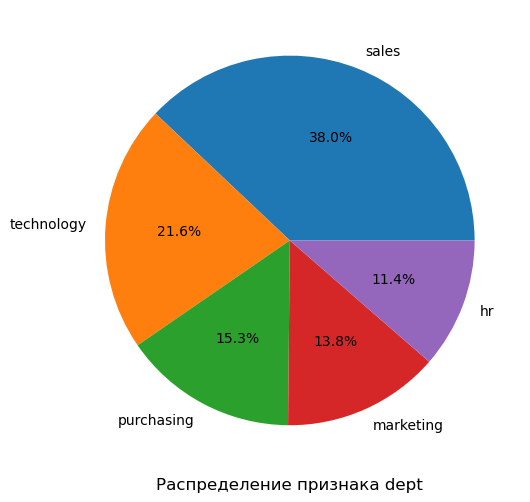

```python
pie_plot('dept', train_job);
```

Мы видим следующую статистику:

- sales - 38%
- technology - 21.6%
- purchasing - 15.3%
- marketing - 13.8%
- hr - 11.4%

Большое кол-во людей задействовано в **продажах**, далее идет группа **технологии**, целевой аудиторией которой являются, скорее всего, сотрудники IT, далее **отдел закупок**, недалеко располагается **отдел маркетинга** и замыкающей группой является **отдел hr**.

#### level

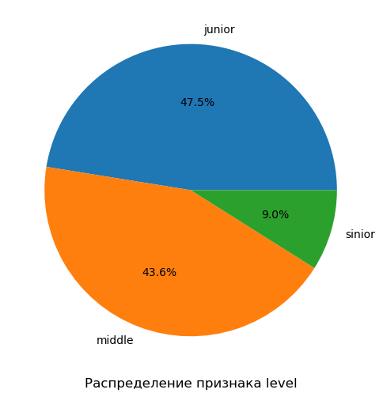

```python
pie_plot('level', train_job)
```

Большую часть выборки составляют **Джуны** и **Мидлы** (почти в равных пропорциях), 9% - **Сеньеры**, что говорит либо о нехватке персонала и массовый найм неопытных специалистов, либо о том, что компания готова обучать людей и открыта для большого кол-ва людей.

#### workload

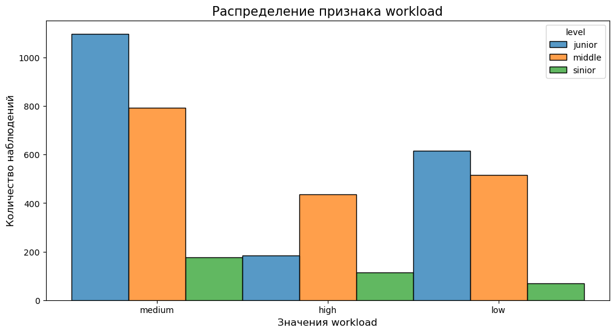

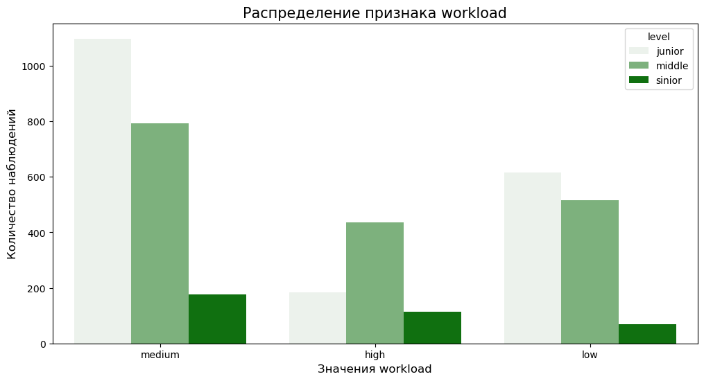

```python
## гистограмма для комментария от студента ниже
hist_plot('workload',
         train_job,
         hue='level',
         multiple='dodge')
count_plot('workload',
          train_job,
          hue='level')
```

Топ занятости:

- medium
- low
- high

Причем мы видим очень интересную картинку в разбиении, а именно то, что в среднем разница между группами по разбиению на мидлов не очень большая на контрасте с разницей в джунах. Несмотря на то, что мидлов немного меньше джунов, их график распределен более равномерно. Джуны же предпочитают работать по большей мере в группе средней и низкой занятости. У сеньеров тоже иное распределение, а именно специалисты такого уровня больше всего предпочитают работать по среднему графику, на втором месте - высокая загруженность, ну а самой непопулярной занятостью является низкая.

#### employment_years

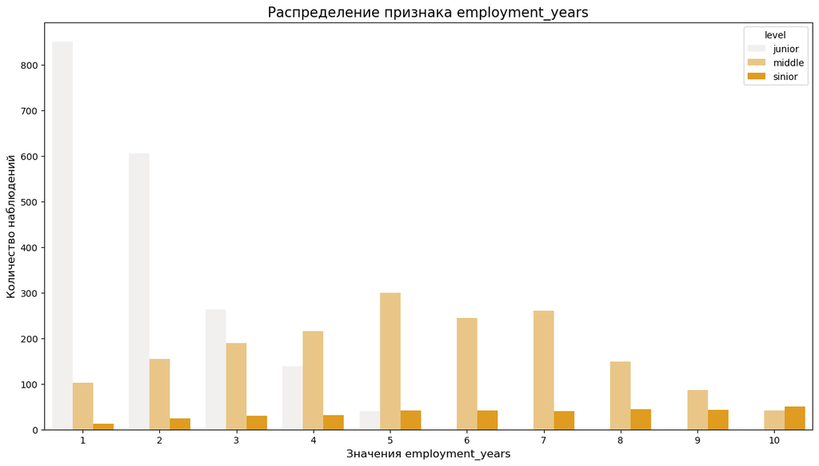

```python
count_plot('employment_years',
              train_job,
              figsize=(15, 8),
              hue='level',
              color='orange'
              )
```

Как мы видим, большие части сотрудников сосредоточены в последние 6 лет работы, то есть те, кто работает >=7 лет - старички.

Касаемо разбиения на уровни: мы видим, что большая часть джунов сосредоточена в первых 3 годах, мидлы имеют распределение, которое чем-то походит на нормальное (только значения дискретные), сеньеры же имеют линейную тенденцию: чем больше стаж, тем больше кол-во сеньеров. Это говорит о том, что с течением времени набор в компанию сеньеров становится меньше. Этот факр стоит учесть.

#### last_year_promo

```python
train_job['last_year_promo'].value_counts()
```

```
last_year_promo
no     3880
yes     120
Name: count, dtype: int64
```

Как мы видим, большая часть выборки не повысилась за последний год, поэтому посмотрим лишь на тех, кто повысился:

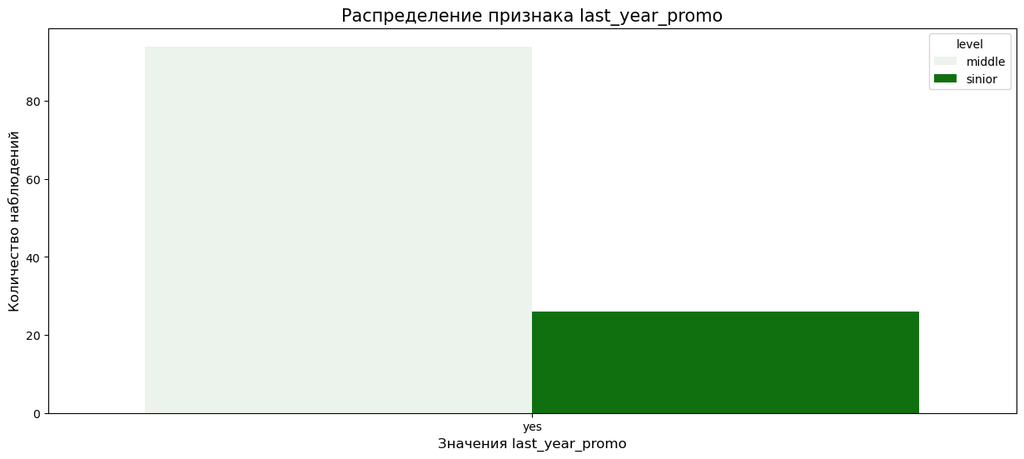

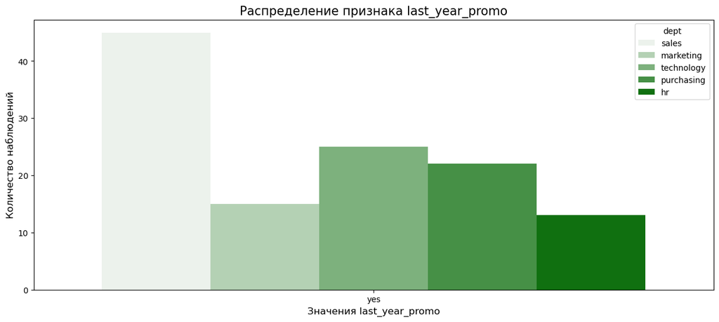

```python
count_plot('last_year_promo',
          train_job.query('last_year_promo == "yes"'),
          hue='level',
          figsize=(15, 6))
count_plot('last_year_promo',
          train_job.query('last_year_promo == "yes"'),
          hue='dept',
          figsize=(15, 6))
```

По поводу повышения при разбиении по уровню все очевидно: позади джунов никого нет, мидлы повышаются больше, чем сеньеры, так как джунов больше и порог повышения на сеньера гораздо больше и труднее, чем на мидла.

Ссылаясь на анализ признака **dept**:

- Не удивительно то, что большое кол-во повышений видно у группы продаж, далее идет еще одна крупная группа работников - технологии;
- Интересно наблюдать то, что группа закупок гораздо ближе по процентному соотношению к размерам отдела **marketing**, хотя по кол-ву повышений она конкурирует с technology, что говорит о ней, как о более мобильной группе в данном бизнесе;
- **marketing** и **hr** находятся на равных, причем в группе hr меньше сотрудников, что подвигает нас на мысль, что в этом году меньше всего получили повышение отдел маркетига.

#### last_year_violations

```python
train_job.last_year_violations.value_counts()
```

```
last_year_violations
no     3441
yes     559
Name: count, dtype: int64
```

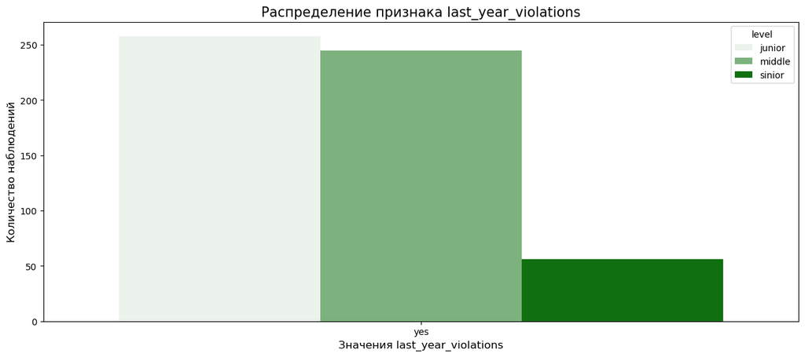

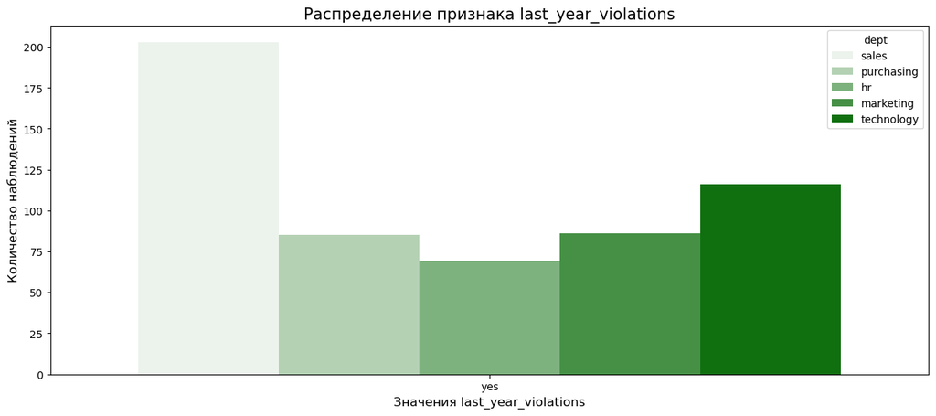

```python
count_plot('last_year_violations',
          train_job.query('last_year_violations == "yes"'),
          hue='level',
          figsize=(15, 6))
count_plot('last_year_violations',
          train_job.query('last_year_violations == "yes"'),
          hue='dept',
          figsize=(15, 6))
```

По поводу разбиения по уровням квалификаций, то здесь ничего интересного, так как пропорции подобны процентному соотшению групп;

Разбиение по признаку отдела бизнеса также не дало чего-то интересного, так как пропорции подобны процентному соотшению групп;

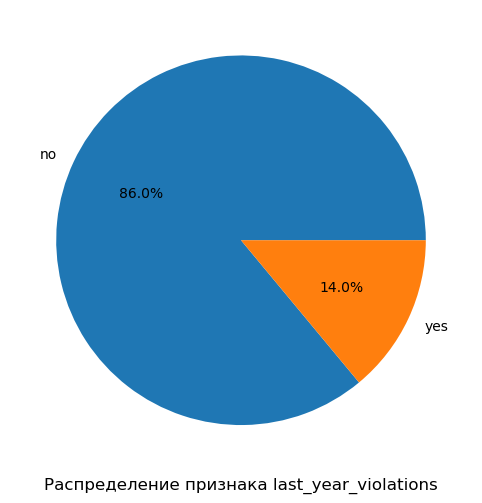

```python
pie_plot('last_year_violations',
         train_job)
```

Мы видим следующую статистику:

- 86% - не нарушали правила с прошедший год
- 14% - нарушало

Очень сложный параметр для объективной оценки, так как компании бывают разные и правила у всех тоже рознятся, ведь правила могут быть очень строгими или наоборот достаточно лояльными к работникам, но по личным ощущениям `86%` ненарушающих - хороший показатель

#### supervisor_evaluation

```python
train_job.supervisor_evaluation.unique()
```

```
array([1, 5, 2, 3, 4])
```

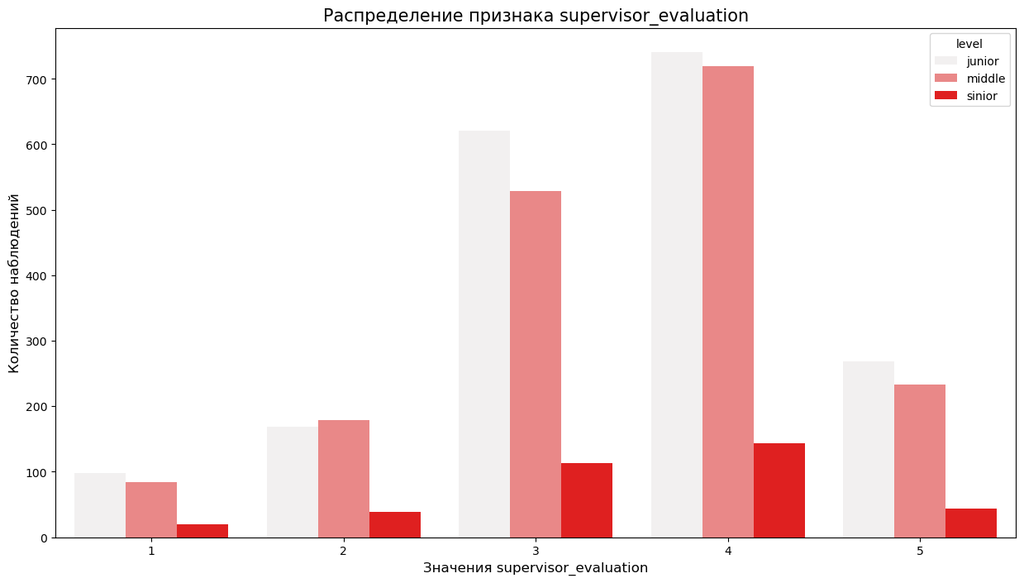

```python
count_plot('supervisor_evaluation',
             train_job,
             figsize=(15, 8),
             hue='level',
             color='red')
```

Мы видим, что основная часть выборки имеет оценки 3-4, и достаточно малая часть имеет оценки 5 и 1-2.

По `count_plot` и разбиению на уровни мы ничего особого не видем, в каждой оценке имеется приблизительно одинаковое соотношение по уровням, подобно распределению признака **level**. Мы можем сделать выввод, что сотрудники зачастую выполняют задачи на 3-4 балла, что, естественно не очень хорошо для начальников и управленцев, однако люди справляются, радует.

#### salary

```python
train_job.salary.unique()
```

```
array([24000, 38400, 12000, 18000, 22800, 30000, 56400, 52800, 13200,
       54000, 19200, 40800, 34800, 27600, 26400, 33600, 50400, 15600,
       14400, 25200, 72000, 31200, 32400, 48000, 43200, 46800, 58800,
       84000, 44400, 39600, 37200, 21600, 28800, 62400, 60000, 42000,
       49200, 55200, 57600, 68400, 45600, 51600, 64800, 80400, 20400,
       61200, 76800, 69600, 16800, 36000, 63600, 81600, 66000, 74400,
       67200, 70800, 73200, 75600, 79200, 94800, 78000, 88800, 92400,
       85200, 91200, 98400, 96000, 97200])
```

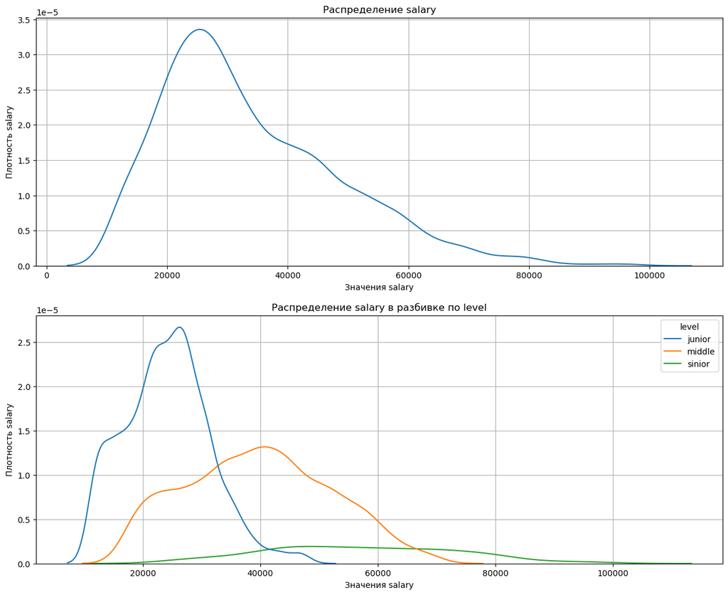

```python
kde_plot('salary', 'level',train_job)
```

#### job_satisfaction_rate

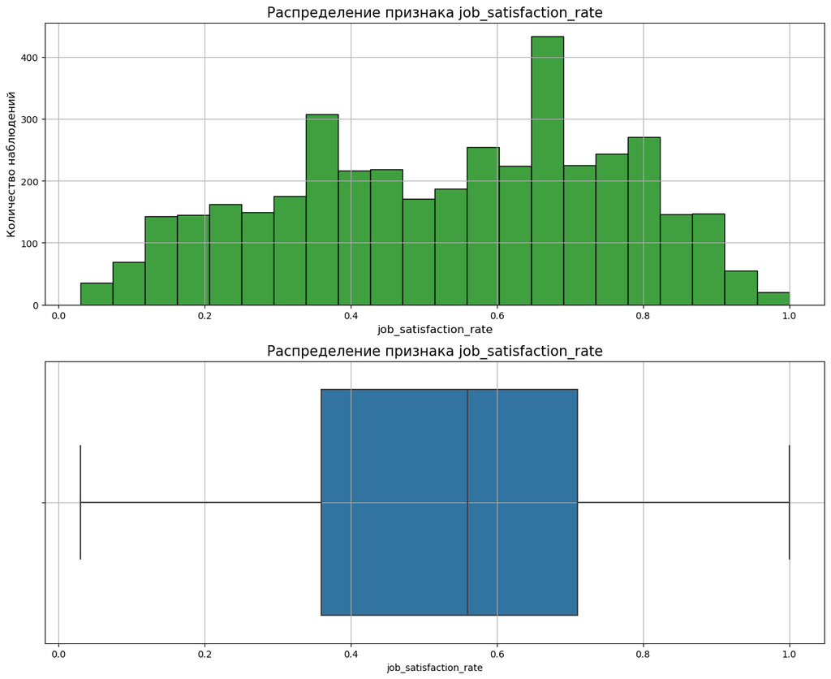

```python
hist_box_plot('job_satisfaction_rate',
         train_job,
         figsize=(15, 12))
```

```python
display(train_job.job_satisfaction_rate.describe().to_frame())
train_job.groupby(['level', 'dept'])['job_satisfaction_rate'].agg(['median', 'mean'])
```

|  | job_satisfaction_rate |
| --- | --- |
| count | 4000.000000 |
| mean | 0.533995 |
| std | 0.225327 |
| min | 0.030000 |
| 25% | 0.360000 |
| 50% | 0.560000 |
| 75% | 0.710000 |
| max | 1.000000 |

| level | dept | median | mean |
| --- | --- | --- | --- |
| junior | hr | 0.510 | 0.501193 |
|  | marketing | 0.550 | 0.544111 |
|  | purchasing | 0.590 | 0.547372 |
|  | sales | 0.550 | 0.514569 |
|  | technology | 0.550 | 0.519341 |
| middle | hr | 0.600 | 0.567720 |
|  | marketing | 0.500 | 0.504890 |
|  | purchasing | 0.580 | 0.554084 |
|  | sales | 0.610 | 0.563724 |
|  | technology | 0.545 | 0.533053 |
| sinior | hr | 0.610 | 0.565333 |
|  | marketing | 0.520 | 0.503774 |
|  | purchasing | 0.590 | 0.566364 |
|  | sales | 0.460 | 0.485349 |
|  | technology | 0.550 | 0.531974 |

Итак, по графикам мы видим, что большая часть оценок варьируется от 0.36 до 0.71 по шкале от 0 до 1. Распределение таково, что частично оно походит на нормальное, однако есть некоторые высоты, в районе 0.7 и. 0.38.

- Мы видим, что в разделе **Junior** мы наблюдаем, что по показателю медианы и среднего наибольшую оценку имеет отдел **purchasing**, причем по средней оценке ближе всего находится **marketing**, несмотря на отстающую медиану. Это говорит нам о том, что есть немалое число положительных оценок от этого отдела, но большинство все равно ставит оценку ниже;
- В разделе **Middle** ситуация иная, а именно лидерами являются категории **hr** и **sales**, причем **hr** лидирует в средней оценке, а **sales**, в любом случае это говорит о том, что специалисты среднего уровня ставят усредненную наибольшую оценку именно из вышеупомянутых отделов.
- В разделе **Sinior** ситуация немного поменялась, лидерами по наиболее высокой усредненной оценке являются люди из отдела **hr** и **purchasing**, причем у **hr** медиана больше.
- Также стоит отметить, что у джунов наиболее недовольными оказываются **hr**, у мидлов - **marketing**, у сеньеров - **sales**.

### test_features

Исследуем **test_features**, однако мы не будем писать лишних слов и выводов, если какой-то признак будет идентичен **train_job**. Комментарии будут даваться на интересных местах различия признаков выборок. Для корректного анализа соединим целевой признак с тестовым датасетом во временный датасет **time_test_features**:

```python
time_test_features = pd.merge(test_features, test_target, how='left', on='id')
time_test_features.head()
```

|  | id | dept | level | workload | employment_years | last_year_promo | last_year_violations | supervisor_evaluation | salary | job_satisfaction_rate |
| --- | --- | --- | --- | --- | --- | --- | --- | --- | --- | --- |
| 0 | 485046 | marketing | junior | medium | 2 | no | no | 5 | 28800 | 0.79 |
| 1 | 686555 | hr | junior | medium | 1 | no | no | 4 | 30000 | 0.72 |
| 2 | 467458 | sales | middle | low | 5 | no | no | 4 | 19200 | 0.64 |
| 3 | 418655 | sales | middle | low | 6 | no | no | 4 | 19200 | 0.60 |
| 4 | 789145 | hr | middle | medium | 5 | no | no | 5 | 40800 | 0.75 |

#### dept

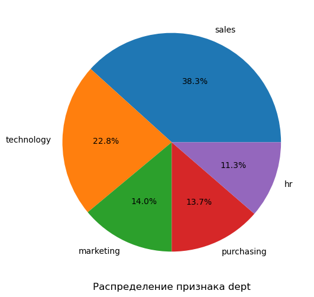

```python
pie_plot('dept', time_test_features);
```

Видим небольшую разницу во всех группах, однако она не критична.

#### level

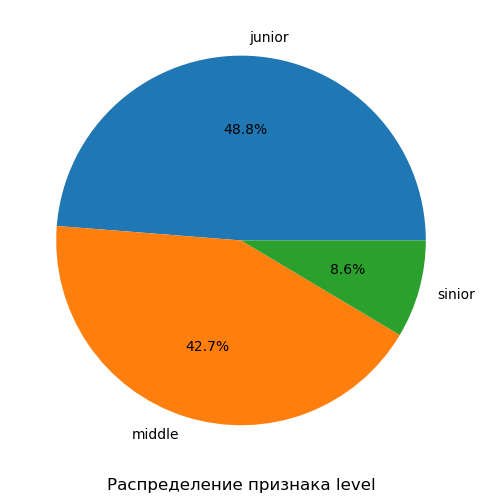

```python
pie_plot('level', time_test_features);
```

#### workload

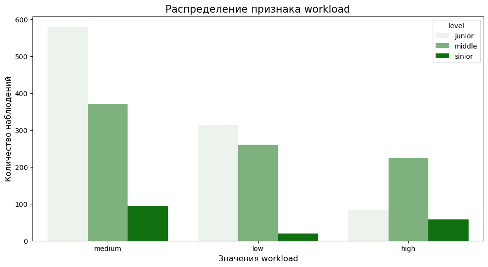

```python
count_plot('workload',
          time_test_features,
          hue='level')
```

Кроме того факта, что тестовая выборка в два раза меньше обучающей, то разница в разбивке по квалификациям на уровне погрешности.

#### employment_years

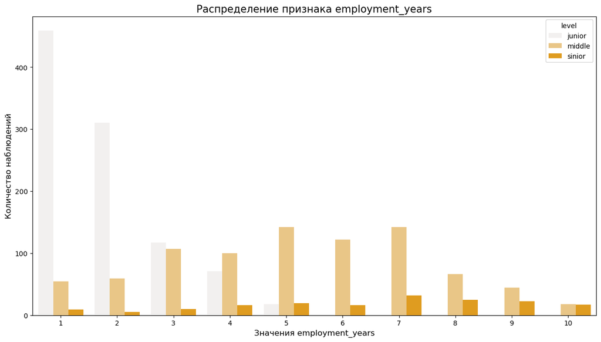

```python
count_plot('employment_years',
              time_test_features,
              figsize=(15, 8),
              hue='level',
              color='orange'
              )
```

#### last_year_promo

```python
time_test_features['last_year_promo'].value_counts()
```

```
last_year_promo
no     1937
yes      63
Name: count, dtype: int64
```

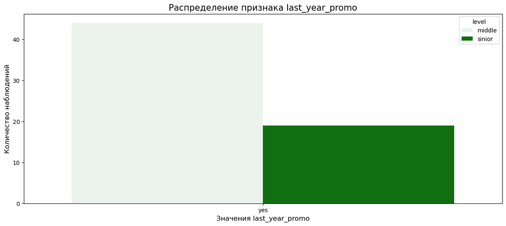

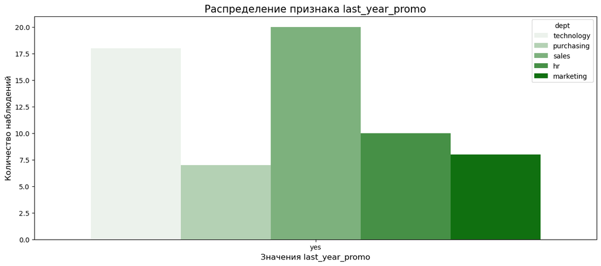

```python
count_plot('last_year_promo',
          time_test_features.query('last_year_promo == "yes"'),
          hue='level',
          figsize=(15, 6))
count_plot('last_year_promo',
          time_test_features.query('last_year_promo == "yes"'),
          hue='dept',
         figsize=(15, 6))
```

**Интересное**: было замечено, что в процентном соотношении люди, которых повысили немного больше.

#### last_year_violations

```python
time_test_features.last_year_violations.value_counts()
```

```
last_year_violations
no     1738
yes     262
Name: count, dtype: int64
```

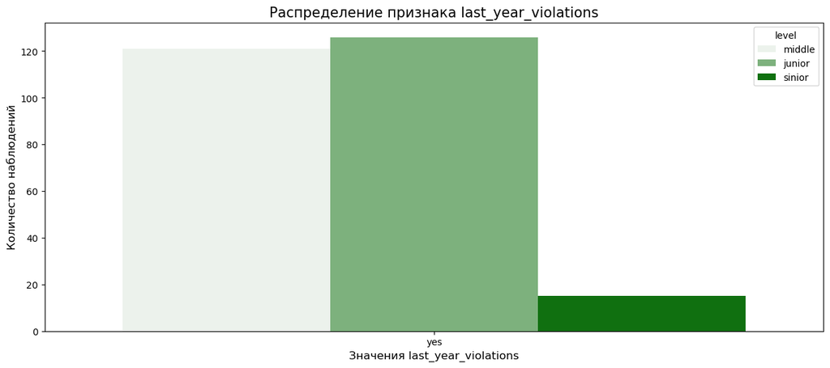

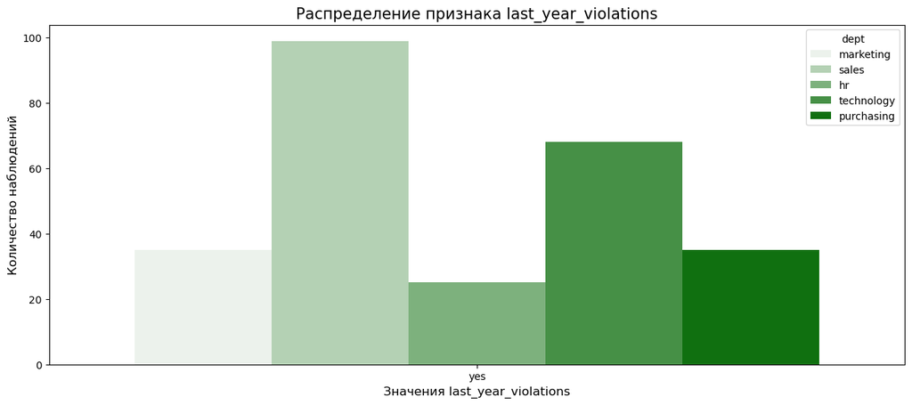

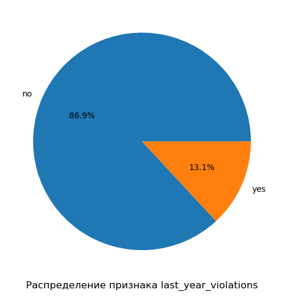

```python
count_plot('last_year_violations',
          time_test_features.query('last_year_violations == "yes"'),
          hue='level',
          figsize=(15, 6))
count_plot('last_year_violations',
          time_test_features.query('last_year_violations == "yes"'),
          hue='dept',
          figsize=(15, 6))
pie_plot('last_year_violations', time_test_features)
```

**Интересно**: в тестовой выборке наблюдается на 0.9% работников, которые нарушали правила, меньше.

#### supervisor_evaluation

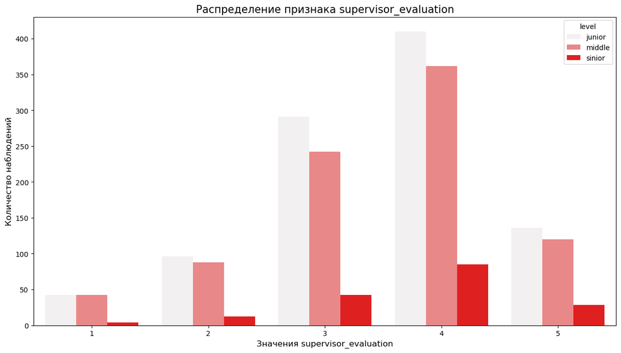

```python
count_plot('supervisor_evaluation',
             time_test_features,
             figsize=(15, 8),
             hue='level',
             color='red')
```

#### salary

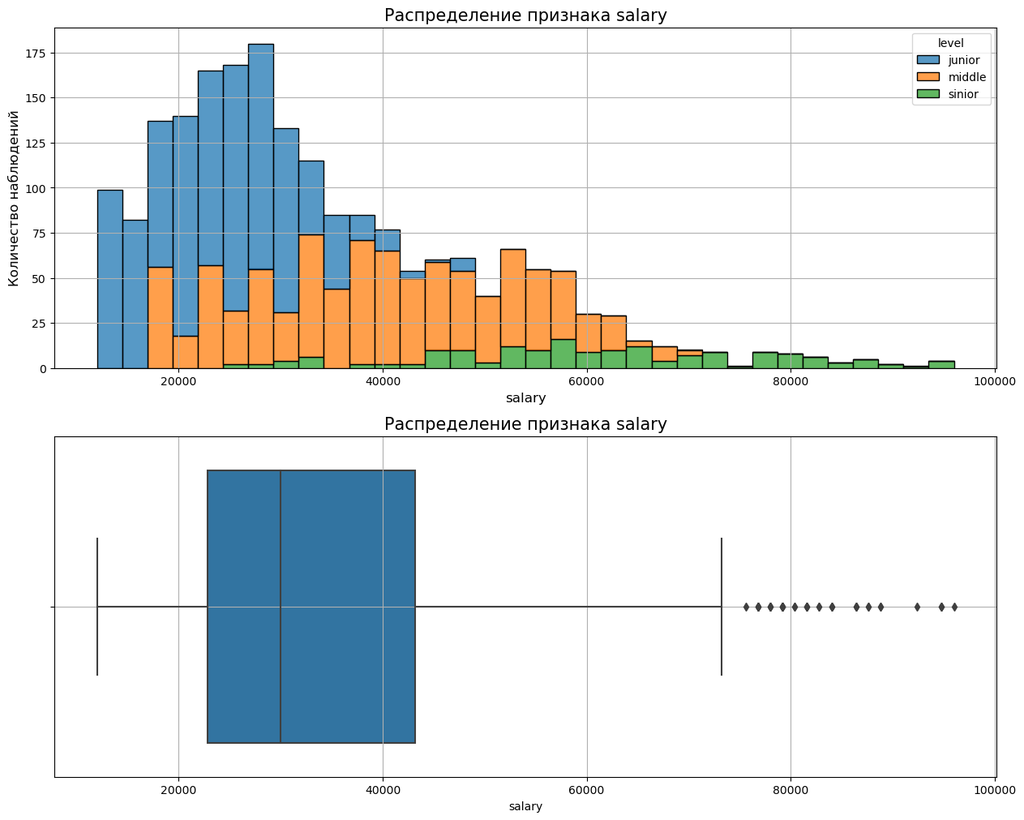

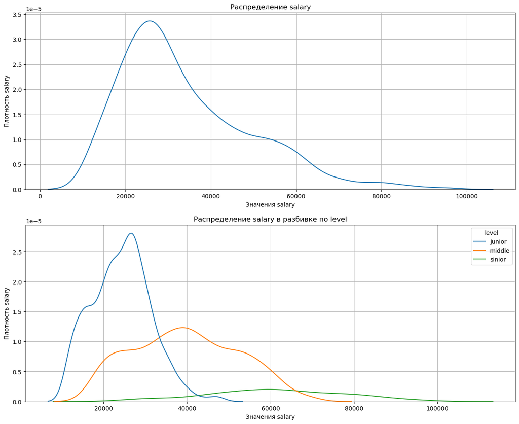

```python
hist_box_plot('salary',
              time_test_features,
              figsize=(15, 12),
              hue='level',
              multiple='stack',
             bins=34)
kde_plot('salary', 'level', time_test_features)
```

#### job_satisfaction_rate

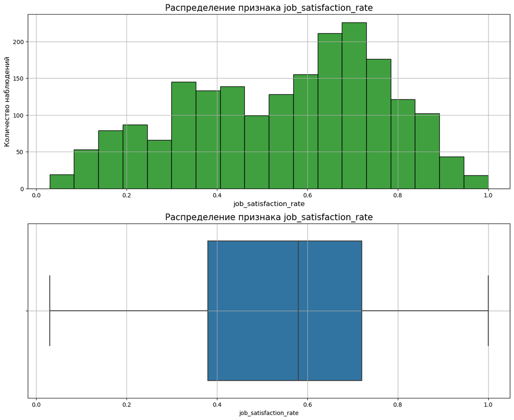

|  | job_satisfaction_rate |
| --- | --- |
| count | 2000.00000 |
| mean | 0.54878 |
| std | 0.22011 |
| min | 0.03000 |
| 25% | 0.38000 |
| 50% | 0.58000 |
| 75% | 0.72000 |
| max | 1.00000 |

| level | dept | median | mean |
| --- | --- | --- | --- |
| junior | hr | 0.550 | 0.528974 |
|  | marketing | 0.590 | 0.570310 |
|  | purchasing | 0.560 | 0.550373 |
|  | sales | 0.555 | 0.532196 |
|  | technology | 0.550 | 0.507834 |
| middle | hr | 0.590 | 0.561538 |
|  | marketing | 0.610 | 0.540229 |
|  | purchasing | 0.560 | 0.539664 |
|  | sales | 0.630 | 0.571600 |
|  | technology | 0.570 | 0.535000 |
| sinior | hr | 0.630 | 0.588421 |
|  | marketing | 0.610 | 0.611579 |
|  | purchasing | 0.675 | 0.629500 |
|  | sales | 0.680 | 0.617302 |
|  | technology | 0.685 | 0.605200 |

```python
hist_box_plot('job_satisfaction_rate',
         time_test_features,
         figsize=(15, 12))

display(time_test_features
        .job_satisfaction_rate
        .describe()
        .to_frame())
(time_test_features
 .groupby(['level', 'dept'])['job_satisfaction_rate']
 .agg(['median', 'mean'])
)
```

**Интересно**: мы видим более равномерное распределение, без резкий выступов, коих в тренировочном 2, IQR боксплота смещен вправо, да и описание этого признака дает нам понять, что в этом датафрейме усредненная оценка немного завышена относительно тренировочного датафрейма.

Также мы видим весомые отличия от тренировочного датафрейма в сводной таблице с разбиение по классификации и отделу, однако это объясняется завышенным усредненным показателем оценки.

#### Подытоживая

Мы увидили несколько интересных отличий от тренировачного датафрейма в следующих признаках:

1) **last_year_promo**: **Интересное**: было замечено, что в процентном соотношении люди, которых повысили немного больше.

2) **last_year_violations**: **Интересно**: в тестовой выборке наблюдается на 0.9% работников, которые нарушали правила, меньше.

3) **job_satisfaction_rate** **Интересно**: мы видим более равномерное распределение, без резкий выступов, коих в тренировочном 2, IQR боксплота смещен вправо, да и описание этого признака дает нам понять, что в этом датафрейме усредненная оценка немного завышена относительно тренировочного датафрейма.

Также мы видим весомые отличия от тренировочного датафрейма в сводной таблице с разбиение по классификации и отделу, однако это объясняется завышенным усредненным показателем оценки.

4) Да, в датафреймах есть различия, они не разбились в точности такиим образом, чтобы распределения были везде одинаковые, однако вектор развития от таких моментов не меняется, двигаемся дальше :)

### Выводы:

#### train_job

1. **dept**
   - sales - 38%
   - technology - 21.6%
   - purchasing - 15.3%
   - marketing - 13.8%
   - hr - 11.4%

     Большое кол-во людей задействовано в **продажах**, далее идет группа **технологии**, целевой аудиторией которой являются, скорее всего, сотрудники IT, далее **отдел закупок**, недалеко располагается **отдел маркетинга** и замыкающей группой является **отдел hr**.
1. **level**

   Большую часть выборки составляют **Джуны** и **Мидлы** (почти в равных пропорциях), 9% - **Сеньеры**, что говорит либо о нехватке персонала и массовый найм неопытных специалистов, либо о том, что компания готова обучать людей и открыта для большого кол-ва людей.
1. **workload**

   Топ занятости:
   - medium
   - low
   - high

     Причем мы видим очень интересную картинку в разбиении, а именно то, что в среднем разница между группами по разбиению на мидлов не очень большая на контрасте с разницей в джунах. Несмотря на то, что мидлов немного меньше джунов, их график распределен более равномерно. Джуны же предпочитают работать по большей мере в группе средней и низкой занятости. У сеньеров тоже иное распределение, а именно специалисты такого уровня больше всего предпочитают работать по среднему графику, на втором месте - высокая загруженность, ну а самой непопулярной занятостью является низкая.
1. **employment_years**

   Как мы видим, большие части сотрудников сосредоточены в последние 6 лет работы, то есть те, кто работает >=7 лет - старички.

   Касаемо разбиения на уровни: мы видим, что большая часть джунов сосредоточена в первых 3 годах, мидлы имеют распределение, которое чем-то походит на нормальное (только значения дискретные), сеньеры же имеют линейную тенденцию: чем больше стаж, тем больше кол-во сеньеров. Это говорит о том, что с течением времени набор в компанию сеньеров становится меньше. Этот факр стоит учесть.
1. **last_year_promo**

   Ссылаясь на анализ признака **dept**:
   - Не удивительно то, что большое кол-во повышений видно у группы продаж, далее идет еще одна крупная группа работников - технологии;
   - Интересно наблюдать то, что группа закупок гораздо ближе по процентному соотношению к размерам отдела **marketing**, хотя по кол-ву повышений она конкурирует с technology, что говорит о ней, как о более мобильной группе в данном бизнесе;
   - **marketing** и **hr** находятся на равных, причем в группе hr меньше сотрудников, что подвигает нас на мысль, что в этом году меньше всего получили повышение отдел маркетига.
1. **last_year_violations**

   Мы видим следующую статистику:
   - 86% - не нарушали правила с прошедший год
   - 14% - нарушало

     Очень сложный параметр для объективной оценки, так как компании бывают разные и правила у всех тоже рознятся, ведь правила могут быть очень строгими или наоборот достаточно лояльными к работникам, но по личным ощущениям `86%` ненарушающих - хороший показатель.
1. **supervisor_evaluation** Мы видим, что основная часть выборки имеет оценки 3-4, и достаточно малая часть имеет оценки 5 и 1-2.

   По `count_plot` и разбиению на уровни мы ничего особого не видем, в каждой оценке имеется приблизительно одинаковое соотношение по уровням, подобно распределению признака **level**. Мы можем сделать выввод, что сотрудники зачастую выполняют задачи на 3-4 балла, что, естественно не очень хорошо для начальников и управленцев, однако люди справляются, радует.
1. **salary**

   Распределение признака **salary** таково, что большая часть выборки находится в интервале от 22 тыс. до чуть более 40 тыс.Ссылаясь на распределение и разбиение по признаку **level** мы видим то, что разброс у **Sinior** специалистов намного больше, у **Middle** - средний, а у **Junior** - меньше всего. Это как раз-таки связано с распределением занятости людей: джуны предпочитают среднюю и низкую занятость, мидлы - равномерно распределены, сеньеры линейно от высокой к низкой;
1. **job_satisfaction_rate**

   Итак, по графикам мы видим, что большая часть оценок варьируется от 0.36 до 0.71 по шкале от 0 до 1. Распределение таково, что частично оно походит на нормальное, однако есть некоторые высоты, в районе 0.7 и. 0.38.
   - Мы видим, что в разделе **Junior** мы наблюдаем, что по показателю медианы и среднего наибольшую оценку имеет отдел **purchasing**, причем по средней оценке ближе всего находится **marketing**, несмотря на отстающую медиану. Это говорит нам о том, что есть немалое число положительных оценок от этого отдела, но большинство все равно ставит оценку ниже;
   - В разделе **Middle** ситуация иная, а именно лидерами являются категории **hr** и **sales**, причем **hr** лидирует в средней оценке, а **sales**, в любом случае это говорит о том, что специалисты среднего уровня ставят усредненную наибольшую оценку именно из вышеупомянутых отделов.
   - В разделе **Sinior** ситуация немного поменялась, лидерами по наиболее высокой усредненной оценке являются люди из отдела **hr** и **purchasing**, причем у **hr** медиана больше.
   - Также стоит отметить, что у джунов наиболее недовольными оказываются **hr**, у мидлов - **marketing**, у сеньеров - **sales**.

#### test_features + test_target

Мы увидили несколько интересных отличий от тренировачного датафрейма в следующих признаках:

1) **last_year_promo**: **Интересное**: было замечено, что в процентном соотношении люди, которых повысили немного больше.

2) **last_year_violations**: **Интересно**: в тестовой выборке наблюдается на 0.9% работников, которые нарушали правила, меньше.

3) **job_satisfaction_rate** **Интересно**: мы видим более равномерное распределение, без резкий выступов, коих в тренировочном 2, IQR боксплота смещен вправо, да и описание этого признака дает нам понять, что в этом датафрейме усредненная оценка немного завышена относительно тренировочного датафрейма.

Также мы видим весомые отличия от тренировочного датафрейма в сводной таблице с разбиение по классификации и отделу, однако это объясняется завышенным усредненным показателем оценки.

4) Да, в датафреймах есть различия, они не разбились в точности такиим образом, чтобы распределения были везде одинаковые, однако вектор развития от таких моментов не меняется, двигаемся дальше :)

### Подготовка признаков:

1. При масштабировании категориальных признаков будем руководствоваться следующим:
   - **OrdinalEncoder** подходит для категорий с естественным порядком.
   - **OneHotEncoder** подходит для категорий без естественного порядка или с высоким количеством уникальных значений.

Тогда выделим следующие признаки:

- OrdinalEncoder - `level`, `workload`
- OneHotEncoder - `dept`, `last_year_promo`, `last_year_violations`
1. При масштабировании категориальных признаков будем руководствоваться следующим:
   - **Диапазон значений**: StandardScaler приводит данные к нулевому среднему и единичному стандартному отклонению, что не обязательно помещает данные в определённый диапазон. MinMaxScaler приводит данные к заданному диапазону (по умолчанию [0, 1]).
   - **Масштаб данных**: StandardScaler учитывает распределение данных (среднее и стандартное отклонение), что делает его полезным для алгоритмов, которые предполагают нормальное распределение признаков. MinMaxScaler не зависит от распределения данных и просто нормализует их в определённый диапазон, что может быть полезно для некоторых типов алгоритмов.

Ссылаясь на эти правила отнесем признаки в следующие скелеры и признаки:

- StandardScaler - `employment_years`, `salary`
- MinMaxScaler - `supervisor_evaluation`

## Подготовка данных

Построим корреляционную матрицу

```python
train_job.columns
```

```
Index(['id', 'dept', 'level', 'workload', 'employment_years',
       'last_year_promo', 'last_year_violations', 'supervisor_evaluation',
       'salary', 'job_satisfaction_rate'],
      dtype='object')
```

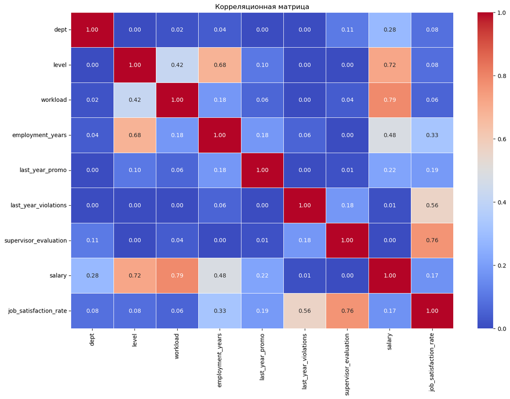

```python
plt.figure(figsize=(15, 10))
sns.heatmap(train_job
            .drop('id', axis=1)
            .phik_matrix(interval_cols=['job_satisfaction_rate', 'salary']),
            annot=True,
            fmt='.2f',
            linewidth=.5,
            cmap='coolwarm');
plt.title('Корреляционная матрица');
```

Ссылаясь на корреляционную матрицу, выделим следующие интересные зависимости:

- **salary** - **level**
- **salary** - **workload**
- **job_satisfaction_rate** - **supervisor_evaluation**
- **employment_years** - **level**.

Мультиколлинеарности в данных не наблюдается.

Посмотрим на интересные признаки:

### salary - level

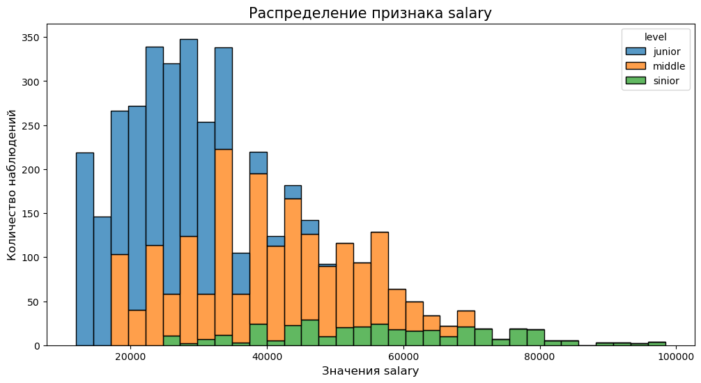

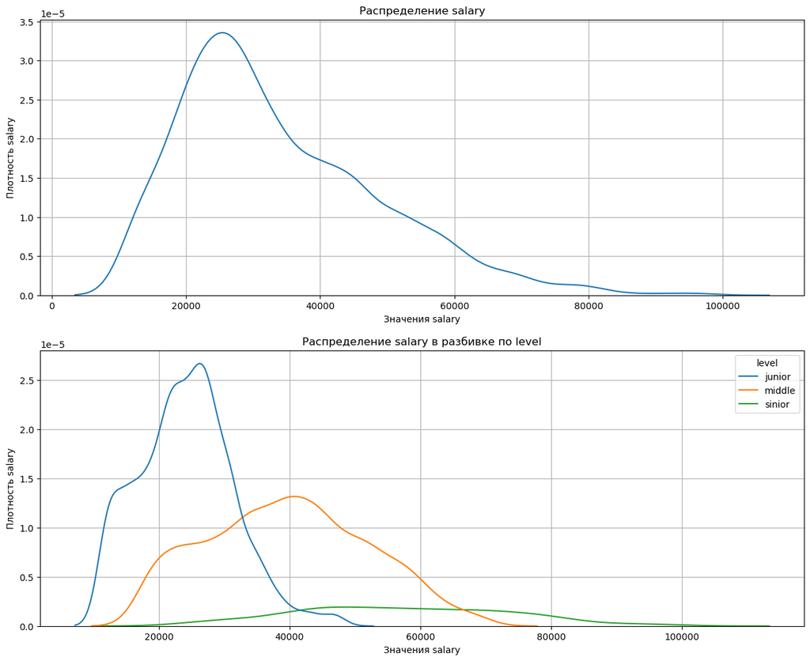

```python
hist_plot('salary',
          train_job,
          hue='level',
          multiple='stack')
kde_plot('salary',
         'level',
          train_job)
```

Здесь это вполне очевидный факт и в реальной жинзни, это было видно еще в исследовательском анализе, мы видим достаточно сильную зависимость между з/п и уровнем квалификации, конечно же мы видим, что **junior** накладывается на **middle** и на **senior**, а **middle** накладывается на **senior**, однако в среднем, конечно же, зп более квалифицированного специалиста в своей области будет выше, так что эта закономерность линейна и в реальной жизни при любых обстоятельствах.

### salary - workload

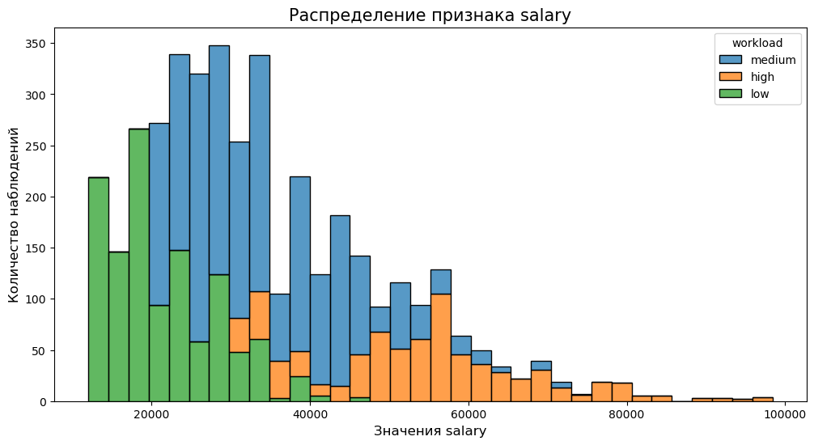

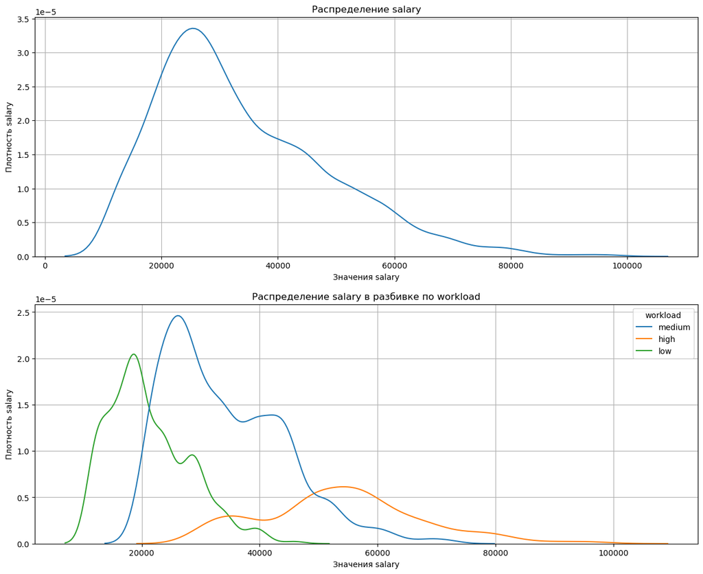

```python
hist_plot('salary',
          train_job,
          hue='workload',
          multiple='stack')
kde_plot('salary', 'workload', train_job)
```

Опять же, наблюдаем аналогичную ситацию, описанную ранее. Тем больше ты работаешь, тем больше в выбранной тобой сфере и месте тебе платят;